# Characterising Online Private Treaty Negotiations

Field Evidence from Irish Residential Property

Damien Dupré and Healy Hynes

## A Real Bidding War

[interactive chart not shown]

## the Irish market is changing …

- Irish property market shifting from **opaque, agent-mediated** negotiations to **transparent digital platforms**
- Online platforms allow buyers to observe competing bids in real time
- Perceived as **fairer** by a majority of the public (Robertson et al., 2026)
- But little is known on the impact of this new technology on the actual bidding behaviour.
- [Robertson, D., Shier, A. J., Timmons, S., & Lunn, P. (2026). Buying and selling property in Ireland: Behavioural evidence on bidding systems, stressors and market comprehension. *ESRI Research Series No 226*](https://www.esri.ie/publications/buying-and-selling-property-in-ireland-behavioural-evidence-on-bidding-systems)

## Data

- **Source:** Anonymised transactional logs from an online offer management platform in Ireland (2018–2024)
- **Each record**: timestamp, property-scoped buyer ID, offer amount (€), property ID
- **After filtering** (negotiations with 2+ participants):

| Metric | Value |
| --- | --- |
| Properties | 574 |
| Unique buyer | 2,148 |
| Top-offer outcomes | 24% |

## Descriptive Analysis

**Property-level measures:**

- Number of active participants
- Total number of offers
- Duration of negotiation window (first to last offer)
- Trajectory of offer escalation

**Participant-level measures:**

- Average offer increment (€ above preceding offer)
- Average response latency (hours between offers)
- Number of offers placed

# Results

## Competition

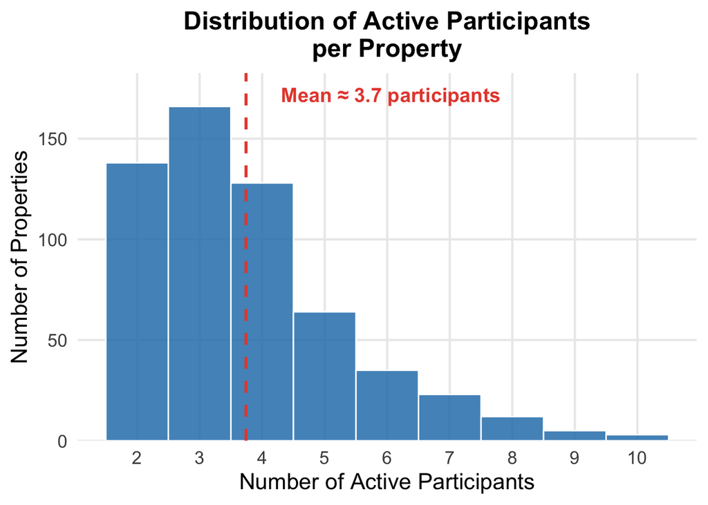

- Most properties attract only 2 or 3 active bidders.
- However, a long tail of highly contested negotiations exists.

## Offer Increments

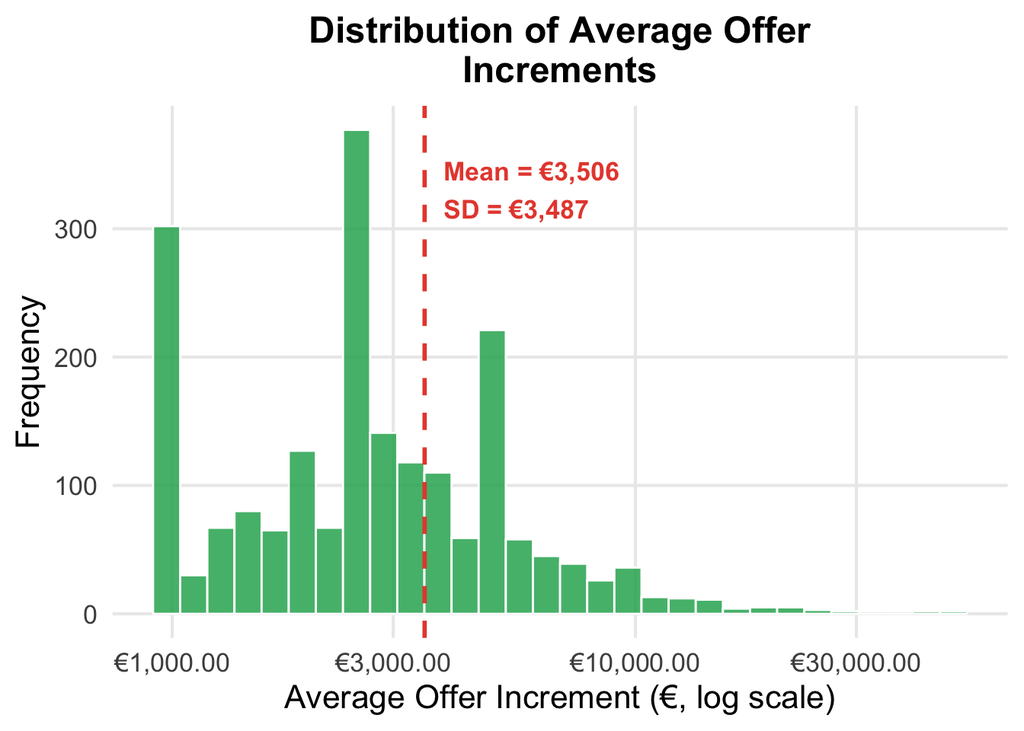

- Bid increments are right-skewed as most are modest, but some buyers make very large jumps to signal commitment.
- Heavy use of €1k, €2.5k, and €5k jumps.

## Response Latency

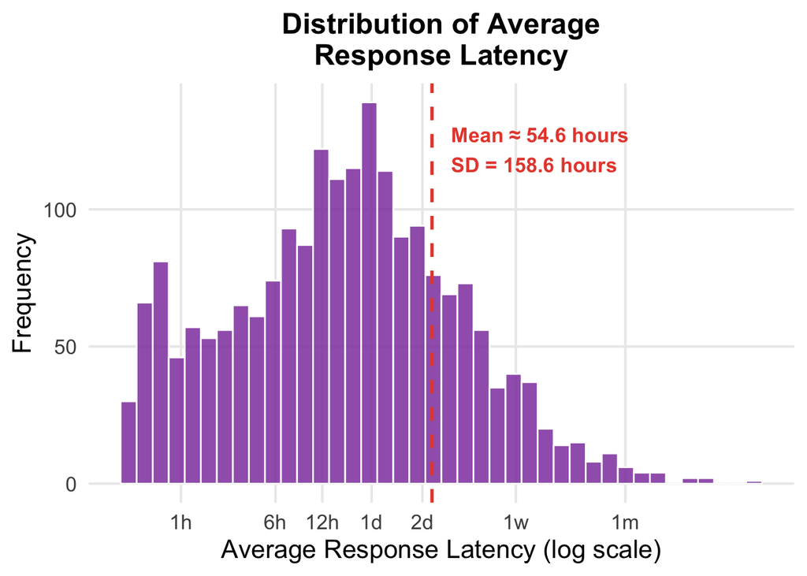

## Competition and Price Premium

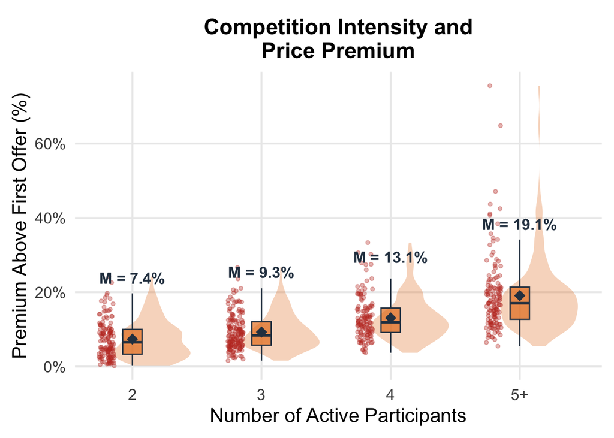

More participants drive higher final prices, consistent with competitive arousal and auction fever dynamics.

## Correlations

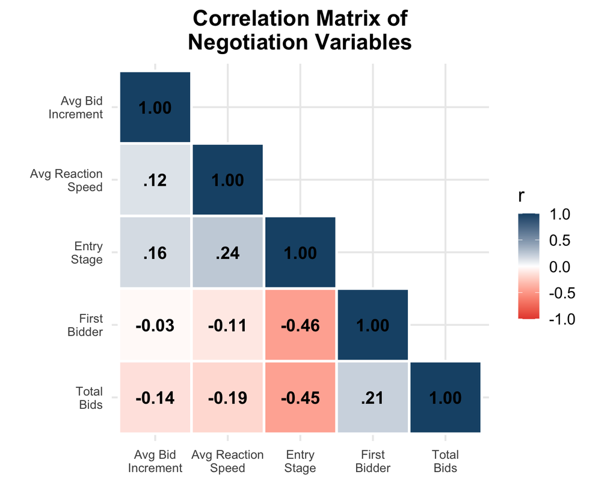

## Discussion & Implications

- Real-world online negotiations involve **meaningful competitive dynamics**, not just passive price discovery
- The association between participation intensity and premiums is consistent with **competitive arousal** (McGee, 2013; Hammervold et al., 2025)
- **Future work:** examination of offer-level behaviours associated with different negotiation outcomes
- [McGee, P. (2013). Bidding in private-value auctions with uncertain values. *Games and Economic Behavior*, 82, 312–326.](https://www.sciencedirect.com/science/article/abs/pii/S0899825613001188)
- [Hammervold, R., Olaussen, J. O., Oust, A., Sommervoll, D. E., & Sønstebø, O. J. (2025). Some like it hot: The effect of auction temperature on urban real estate prices. Real Estate Economics, 53, 1284–1308.](https://doi.org/10.1111/1540-6229.70004)

[interactive chart not shown]

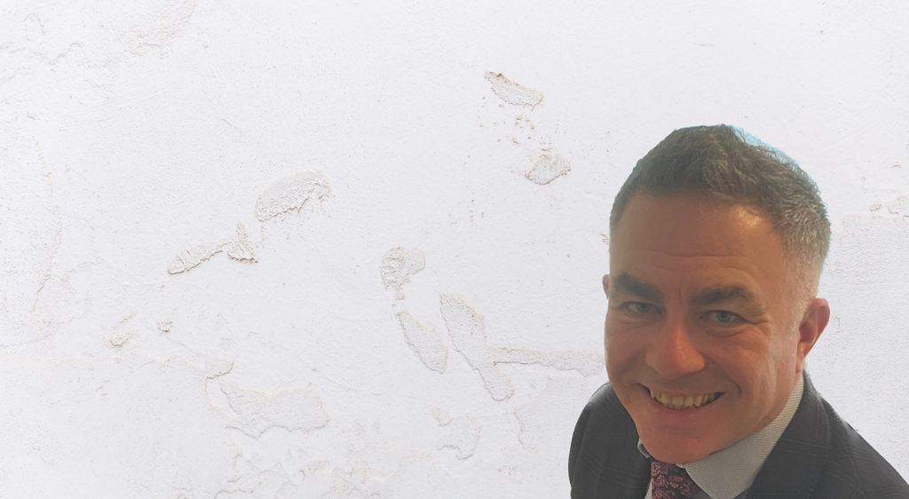

Healy Hynes Beagel, Property Technology | CEO healy.hynes@beagel.com

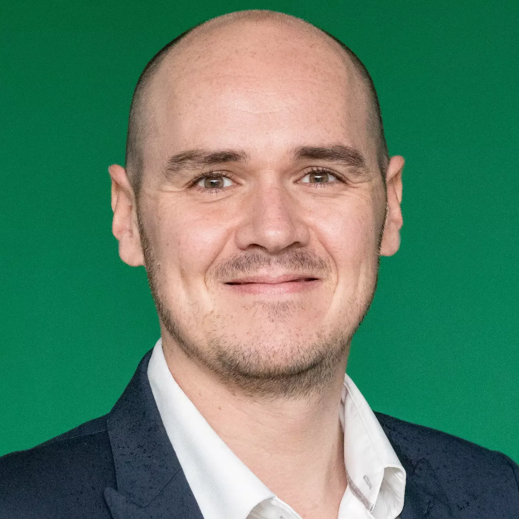

Damien Dupré DCU Business School | Business Research Methods damien.dupre@dcu.ie